# Anti-Stress Intervention Among Physicians (ASIP) Study: Analysis

Author

Valentin Vetter, MD, Msc (valentin.vetter@charite.de)

Published

Last Updated on December 17, 2024

# LOAD LIBRARIES

```r
library(tidyverse)
library(ggplot2)
library(tableone)
library(openxlsx)
library(forcats)
library(ggpubr)
library(gridExtra)
library(lme4)
library(knitr)
library(brms)
library(ggmcmc)
library(ggthemes)
library(ggridges)
library(tableone)
library(knitr)
library(ggExtra)
library(RColorBrewer)
```

# LOAD FUNCTIONS

```r
# setwd("/Users/vetterv/Documents/Universitaet_BSPH/Masterarbeit/Study/Paper/Results_Paper/Code_for_publication/Upload_to_GitHub/code")

source("../code/0_Functions.r")
```

# LOAD DATA

All data was collected anonymously which means that a no point it is possible to allocate the recorded information to an individual. However, as with all anonymous data, the risk of identification remains if the reported number of participants are small and a lot of information is known about the individuals in the source population. Although both does not necessarily apply to the data analyzed here, I chose to upload separated data sets in randomly allocated orders of observations. This allows full replication of the results in the manuscript but avoids the allocation of health data od N-of-1 data to individuals in the very unlikely event that individuals should be re-identified by demographic data.

```r
# Load data from individual N-of-1 studies
## Mindfulness Breathing
ASIP_data_Nof1_MB <- read.csv("../data/ASIP_data_Nof1_MB.csv")

## Box Breathing
ASIP_data_Nof1_BB <- read.csv("../data/ASIP_data_Nof1_BB.csv")

ASIP_data_Nof1_MB_and_BB <- rbind(ASIP_data_Nof1_MB,
                                  ASIP_data_Nof1_BB)
```

```r
# Load data from baseline REDCap Questionnaire
## Demographic Data
data_REDCap_table1_MB_and_BB_dem <- read.csv("../data/data_REDCap_table1_MB_and_BB_dem.csv")

## Health Data
data_REDCap_table1_MB_and_BB_health <- read.csv("../data/data_REDCap_table1_MB_and_BB_health.csv")

## Sex and Stress
## Since sex and stress is also part of the N-of-1 data sets, they are stored in random order separately from the other data sets for anonymity reasons.
data_REDCap_table1_MB_and_BB_sex_and_stress <- read.csv("../data/data_REDCap_table1_MB_and_BB_sex_and_stress.csv")
```

# VECTORS

```r
vec_manuscript_IDs_MB <- as.character(data.frame(table(ASIP_data_Nof1_MB$manuscript_ID))[,1])

vec_manuscript_IDs_BB <- as.character(data.frame(table(ASIP_data_Nof1_BB$manuscript_ID))[,1])
```

# DEFINE PROPERTIES

## Clinical relevance and responder criteria

```r
cut_off_clinically_relevant <- -0.5

probability_responder <- 0.7

Estimate_individual_max <- 5.5
Estimate_individual_min <- -5.5
```

## Colors

```r
color_larger_0 <- brewer.pal(11,"RdYlGn")[5]
color_0_to_clin_relevant <- brewer.pal(11,"RdYlGn")[9]
color_smaller_clin_relevant <- brewer.pal(11,"RdYlGn")[10]
```

## Bayesian Analyses

```r
chains <- 2
iter <- 10000
warmup <- 5000


# set which calculations should be done in the respective run (TRUE = "do the calculation")
calc_indiv_bayesian_models <- FALSE
calc_aggregated_bayesian_models <- FALSE
calc_aggregated_bayesian_models_secondary_analyses <- FALSE
```

# 1. DESCRIPTIVE ANALYSES

## 1.1. REDCap Data

### Table 1

Descriptive statistics of variables assessed at baseline are calculated. As mentioned above, to ensure participant anonymity by preventing (unlikely) re-identification, information used to describe the cohort is stored in seperate, randomly sorted dataset. For easy use, all three datasets are combined here. However, this means that values stored as one observation come from different persons. THEREFORE, ANY ANALYSES OTHER THAN DESCRIPTIVE STATISTICS DOES NOT(!!!) YIELD MEANINGFUL RESULTS! The data can only be used to replicate the descriptive statistics presented in the manuscript. #### Prep Data Set

```r
data_REDCap_table1_MB <- cbind(filter(data_REDCap_table1_MB_and_BB_dem,
                                     intervention == 1),
                              filter(data_REDCap_table1_MB_and_BB_health,
                                     intervention == 1),
                              filter(data_REDCap_table1_MB_and_BB_sex_and_stress,
                                     intervention == 1))
data_REDCap_table1_MB <- fct_polish_REDCap_data(data_REDCap_table1_MB) |> data.frame()


data_REDCap_table1_BB <- cbind(filter(data_REDCap_table1_MB_and_BB_dem,
                                     intervention == 2),
                              filter(data_REDCap_table1_MB_and_BB_health,
                                     intervention == 2),
                              filter(data_REDCap_table1_MB_and_BB_sex_and_stress,
                                     intervention == 2))
data_REDCap_table1_BB <- fct_polish_REDCap_data(data_REDCap_table1_BB) |> data.frame()
```

#### Calculate

```r
# Table 1 with values of participant who chose Mindfulness Breathing
table_1_1 <- table_1_function(data = data_REDCap_table1_MB)
names(table_1_1) <- paste(names(table_1_1), "_MB", sep = "")

# Table 1 with values of participant who chose Box Breathing
table_1_2 <- table_1_function(data = data_REDCap_table1_BB)
names(table_1_2) <- paste(names(table_1_2), "_BB", sep = "")

# Combine tables
table_1_final_strat <- cbind(table_1_1,
                       table_1_2)
rownames(table_1_final_strat) <- c()

write.xlsx(table_1_final_strat,
           "../results/Table_1.xlsx")
```

## 2.1. StudyU Data

### PROs during the week

```r
CreateTableOne(data = ASIP_data_Nof1_MB_and_BB,
               vars = c("survey1_question1_response",
                        "survey1_question2_response"),
               strata = "weekday")
```

```
                                        Stratified by weekday
                                         Friday      Monday      Saturday
  n                                       150         172         144
  survey1_question1_response (mean (SD)) 4.45 (2.26) 4.22 (2.34) 2.95 (2.02)
  survey1_question2_response (mean (SD)) 3.07 (2.05) 4.94 (2.24) 2.86 (2.30)
                                        Stratified by weekday
                                         Sunday      Thursday    Tuesday
  n                                       160         169         178
  survey1_question1_response (mean (SD)) 2.62 (2.06) 4.15 (2.27) 4.74 (2.23)
  survey1_question2_response (mean (SD)) 5.12 (2.54) 4.72 (2.16) 4.75 (2.29)
                                        Stratified by weekday
                                         Wednesday   p      test
  n                                       150
  survey1_question1_response (mean (SD)) 4.65 (2.16) <0.001
  survey1_question2_response (mean (SD)) 4.38 (2.23) <0.001
```

### Line Plots

#### Daily Stress

```r
# Mindfulness Breathing, ABAB, Daily Stress (response 1)
plot_line_all_1ABAB_resp1 <- fct_line_plot_all(data = filter(ASIP_data_Nof1_MB, sequence == "ABAB"),
                                         y_var = "survey1_question1_response",
                                         ylab = "Daily Level of Stress",
                                         title = "Mindfulness Breathing, ABAB")
# Mindfulness Breathing, BABA, Daily Stress
plot_line_all_1BABA_resp1 <- fct_line_plot_all(data = filter(ASIP_data_Nof1_MB, sequence == "BABA"),
                                         y_var = "survey1_question1_response",
                                         ylab = "Daily Level of Stress",
                                         title = "Mindfulness Breathing, BABA")
# Box Breathing, ABAB, Daily Stress
plot_line_all_2ABAB_resp1 <- fct_line_plot_all(data = filter(ASIP_data_Nof1_BB, sequence == "ABAB"),
                                         y_var = "survey1_question1_response",
                                         ylab = "Daily Level of Stress",
                                         title = "Box Breathing, ABAB")
# Box Breathing, BABA, Daily Stress
plot_line_all_2BABA_resp1 <- fct_line_plot_all(data = filter(ASIP_data_Nof1_BB, sequence == "BABA"),
                                         y_var = "survey1_question1_response",
                                         ylab = "Daily Level of Stress",
                                         title = "Box Breathing, BABA")
plot_line_resp1 <- ggarrange(
  plot_line_all_1ABAB_resp1,
  plot_line_all_2ABAB_resp1,
  plot_line_all_1BABA_resp1,
  plot_line_all_2BABA_resp1
)

plot_line_resp1 <- annotate_figure(plot_line_resp1,
                                   top = text_grob("Daily Stress Level", face = "bold", size = 14))

ggsave("../results/Supplementary_Figure_1.jpg",
       plot_line_resp1,
       height = 19,
       width = 22,
       units = "cm")
```

#### Expected stress for next day

```r
# Mindfulness Breathing, ABAB, Daily Stress
plot_line_all_1ABAB_resp2 <- fct_line_plot_all(data = filter(ASIP_data_Nof1_MB, sequence == "ABAB"),
                                         y_var = "survey1_question2_response",
                                         ylab = "Expected Stress Level Next Day",
                                         title = "Mindfulness Breathing, ABAB")
# Mindfulness Breathing, BABA, Daily Stress
plot_line_all_1BABA_resp2 <- fct_line_plot_all(data = filter(ASIP_data_Nof1_MB, sequence == "BABA"),
                                         y_var = "survey1_question2_response",
                                         ylab = "Expected Stress Level Next Day",
                                         title = "Mindfulness Breathing, BABA")
# Box Breathing, ABAB, Daily Stress
plot_line_all_2ABAB_resp2 <- fct_line_plot_all(data = filter(ASIP_data_Nof1_BB, sequence == "ABAB"),
                                         y_var = "survey1_question2_response",
                                         ylab = "Expected Stress Level Next Day",
                                         title = "Box Breathing, ABAB")
# Box Breathing, BABA, Daily Stress
plot_line_all_2BABA_resp2 <- fct_line_plot_all(data = filter(ASIP_data_Nof1_BB, sequence == "BABA"),
                                         y_var = "survey1_question2_response",
                                         ylab = "Expected Stress Level Next Day",
                                         title = "Box Breathing, BABA")
plot_line_resp2 <- ggarrange(
  plot_line_all_1ABAB_resp2,
  plot_line_all_2ABAB_resp2,
  plot_line_all_1BABA_resp2,
  plot_line_all_2BABA_resp2
)

plot_line_resp2 <- annotate_figure(plot_line_resp2,
                                   top = text_grob("Expected Stress Level for the Following Day", face = "bold", size = 14))

ggsave("../results/Supplementary_Figure_2.jpg",
       plot_line_resp2,
       height = 19,
       width = 22,
       units = "cm")
```

# 2. INDIVIDUAL TRIALS

```r
vec_individual_trials_reported_var <- c(
  "ID",
  "Mean_Invt",
  "SD_Invt",
  "n_Invt",
  "Mean_Ctrl",
  "SD_Ctrl",
  "n_Ctrl",
  "Diff",
  "Estimate",
  "l_95.CI",
  "u_95.CI",
  "prob_clinc_effect"
)
```

### 2.1. Daily Stress

```r
# define model
formula_bayes_daily_stress <- as.formula(survey1_question1_response ~ intervention_period  + ar(p = 1))
```

#### 2.1.1. Mindfulness

Calculate:

```r
table_indiv_trials_daily_stress_MB <- fct_individual_trials(data_StudyU = ASIP_data_Nof1_MB,
                                                           vec_ID = vec_manuscript_IDs_MB,
                                                           formula_bayes = formula_bayes_daily_stress)
```

Save:

```r
write.xlsx(
  select(
    table_indiv_trials_daily_stress_MB,
    any_of(vec_individual_trials_reported_var)
  ),
  "../results/Supplementary_Table_1.xlsx"
)
```

#### 2.1.2 Box-Breathing

Calculate:

```r
table_indiv_trials_daily_stress_BB <- fct_individual_trials(data_StudyU = ASIP_data_Nof1_BB,
                                                           vec_ID = vec_manuscript_IDs_BB,
                                                           formula_bayes = formula_bayes_daily_stress)
```

Save:

```r
write.xlsx(
  select(
    table_indiv_trials_daily_stress_BB,
    any_of(vec_individual_trials_reported_var)
  ),
  "../results/Supplementary_Table_2.xlsx"
)
```

### 2.2. Stress on next day

```r
formula_bayes_next_day <- as.formula(survey1_question2_response ~ intervention_period  + ar(p = 1))
```

#### 2.2.1. Mindfulness

Calculate:

```r
table_indiv_trials_next_day_MB <- fct_individual_trials(data_StudyU = ASIP_data_Nof1_MB,
                                                       vec_ID = vec_manuscript_IDs_MB,
                                                       formula_bayes = formula_bayes_next_day)
```

Save:

```r
write.xlsx(
  select(
    table_indiv_trials_next_day_MB,
    any_of(vec_individual_trials_reported_var)
  ),
   "../results/Supplementary_Table_3.xlsx"
)
```

#### 2.2.2 Box-Breathing

Calculate:

```r
table_indiv_trials_next_day_BB <- fct_individual_trials(data_StudyU = ASIP_data_Nof1_BB,
                                                        vec_ID = vec_manuscript_IDs_BB,
                                                        formula_bayes = formula_bayes_next_day)
```

Save:

```r
write.xlsx(
  select(
    table_indiv_trials_next_day_BB,
    any_of(vec_individual_trials_reported_var)
  ),
  "../results/Supplementary_Table_4.xlsx"
)
```

## Plot: Individual Trials Analysis

### Plot A: Pointrange

```r
plot_pointrange_daily_MB <- fct_indiv_trials_pointrange(data = table_indiv_trials_daily_stress_MB,
                                                       title = "Mindfulness Breathing, Daily Stress Level")
plot_pointrange_daily_BB <- fct_indiv_trials_pointrange(data = table_indiv_trials_daily_stress_BB,
                                                       title = "Box Breathing, Daily Stress Level")

plot_pointrange_next_day_MB <- fct_indiv_trials_pointrange(data = table_indiv_trials_next_day_MB,
                                                       title = "Mindfulness Breathing, Stress Next Day")
plot_pointrange_next_day_MB <- fct_indiv_trials_pointrange(data = table_indiv_trials_next_day_BB,
                                                       title = "Box Breathing, Stress Next Day")
```

### Plot B: Barplots

```r
plot_barplot_daily_MB <- fct_indiv_trials_barplot(data = table_indiv_trials_daily_stress_MB,
                                                       title = "Mindfulness Breathing, Daily Stress Level")
plot_barplot_dailyBB <- fct_indiv_trials_barplot(data = table_indiv_trials_daily_stress_BB,
                                                       title = "Box Breathing, Daily Stress Level")

plot_barplot_next_day_MB <- fct_indiv_trials_barplot(data = table_indiv_trials_next_day_MB,
                                                       title = "Mindfulness Breathing, Stress Next Day")
plot_barplot_next_day_BB <- fct_indiv_trials_barplot(data = table_indiv_trials_next_day_BB,
                                                       title = "Box Breathing, Stress Next Day")
```

### Plot A + B

```r
plot_daily_stress <- ggarrange(plot_pointrange_daily_MB,
                               plot_pointrange_daily_BB,
                               plot_barplot_daily_MB,
                               plot_barplot_dailyBB,
                          common.legend = TRUE,
                          legend = "bottom")
ggsave("../results/Figure_2.jpg",
       plot_daily_stress,
       height = 15,
       width = 20,
       units = "cm")



plot_next_day <- ggarrange(plot_pointrange_next_day_MB,
                           plot_pointrange_next_day_MB,
                           plot_barplot_next_day_MB,
                           plot_barplot_next_day_BB,
                          common.legend = TRUE,
                          legend = "bottom")
ggsave("../results/Figure_3.jpg",
       plot_next_day,
       height = 15,
       width = 20,
       units = "cm")
```

# 3. AGGREGATED TRIALS ANALYSIS

To estimate the intervention effects on the population level, all data from each intervention was analyzed together. The Bayesian multilevel model as used for the individual analyses was extended to acknowledge the nested structure of the individual trials.

## Define Formulas

### Daily Stress

```r
formula_bayes_daily_stress <- as.formula(
  survey1_question1_response ~ intervention_period + ar(p = 1) + (intervention_period |
                                                                    manuscript_ID)
)
```

### Expected stress on next day

```r
formula_bayes_next_day <- as.formula(
  survey1_question2_response ~ intervention_period + ar(p = 1) + (intervention_period |
                                                                    manuscript_ID)
)
```

### Calculate Results

#### Primary Analysis

```r
# Calculate results
results_aggregated_primary_analysis <- fct_aggregated_trials_all_together(
  ASIP_data_Nof1_MB = ASIP_data_Nof1_MB,
  ASIP_data_Nof1_BB = ASIP_data_Nof1_BB,
  formula_bayes_daily_stress = formula_bayes_daily_stress,
  formula_bayes_next_day = formula_bayes_next_day
)
# Build report table
results_aggregated_primary_analysis_table <- rbind(
  cbind("Trial" = "Daily Stress, Mindfulness Breathing", results_aggregated_primary_analysis[[1]]),
  cbind("Trial" = "Daily Stress, Box Breathing", results_aggregated_primary_analysis[[3]]),
  cbind("Trial" = "Expected Stress on Next Day, Mindfulness Breathing", results_aggregated_primary_analysis[[5]]),
  cbind("Trial" = "Expected Stress on Next Day, Box Breathing", results_aggregated_primary_analysis[[7]])
)

write.xlsx(results_aggregated_primary_analysis_table,
              "../results/Table_2.xlsx")
```

#### Secondary Analysis

##### Men vs. Women

```r
# prep datasets
## Mindfulness Breathing
ASIP_data_Nof1_MB_sec_women <- filter(ASIP_data_Nof1_MB,
                                  dem_sex_birth == "women")
ASIP_data_Nof1_MB_sec_men <- filter(ASIP_data_Nof1_MB,
                                  dem_sex_birth == "men")

## Box Breathing
ASIP_data_Nof1_BB_sec_women <- filter(ASIP_data_Nof1_BB,
                                  dem_sex_birth == "women")
ASIP_data_Nof1_BB_sec_men <- filter(ASIP_data_Nof1_BB,
                                  dem_sex_birth == "men")

# Calculate Results from subgroups
# women
results_aggregated_secondary_analysis_women <- fct_aggregated_trials_all_together(
  ASIP_data_Nof1_MB = ASIP_data_Nof1_MB_sec_women,
  ASIP_data_Nof1_BB = ASIP_data_Nof1_BB_sec_women,
  formula_bayes_daily_stress = formula_bayes_daily_stress,
  formula_bayes_next_day = formula_bayes_next_day
)
# men
results_aggregated_secondary_analysis_men <- fct_aggregated_trials_all_together(
  ASIP_data_Nof1_MB = ASIP_data_Nof1_MB_sec_men,
  ASIP_data_Nof1_BB = ASIP_data_Nof1_BB_sec_men,
  formula_bayes_daily_stress = formula_bayes_daily_stress,
  formula_bayes_next_day = formula_bayes_next_day
)
# Build report table
results_aggregated_secondary_analysis_sex <- rbind(
  # women
  cbind("Trial" = "Daily Stress, Mindfulness Breathing",
        results_aggregated_secondary_analysis_women[[1]],
        "Group" = "women"),
  cbind("Trial" = "Daily Stress, Box Breathing",
        results_aggregated_secondary_analysis_women[[3]],
        "Group" = "women"),
  cbind("Trial" = "Expected Stress on Next Day, Mindfulness Breathing",
        results_aggregated_secondary_analysis_women[[5]],
        "Group" = "women"),
  cbind("Trial" = "Expected Stress on Next Day, Box Breathing",
        results_aggregated_secondary_analysis_women[[7]],
        "Group" = "women"),
  # men
    cbind("Trial" = "Daily Stress, Mindfulness Breathing",
        results_aggregated_secondary_analysis_men[[1]],
        "Group" = "men"),
  cbind("Trial" = "Daily Stress, Box Breathing",
        results_aggregated_secondary_analysis_men[[3]],
        "Group" = "men"),
  cbind("Trial" = "Expected Stress on Next Day, Mindfulness Breathing",
        results_aggregated_secondary_analysis_men[[5]],
        "Group" = "men"),
  cbind("Trial" = "Expected Stress on Next Day, Box Breathing",
        results_aggregated_secondary_analysis_men[[7]],
        "Group" = "men")
)


write.xlsx(results_aggregated_secondary_analysis_sex,
           "../results/Supplementary_Table_5.xlsx")
```

##### low vs. high Stress

```r
# prep datasets
## Mindfulness Breathing
ASIP_data_Nof1_MB_sec_low_stress <- filter(ASIP_data_Nof1_MB,
                                       stress_group == "low_stress")
ASIP_data_Nof1_MB_sec_high_stress <- filter(ASIP_data_Nof1_MB,
                                        stress_group == "high_stress")

## Box Breathing
ASIP_data_Nof1_BB_sec_low_stress <- filter(ASIP_data_Nof1_BB,
                                       stress_group == "low_stress")
ASIP_data_Nof1_BB_sec_high_stress <- filter(ASIP_data_Nof1_BB,
                                        stress_group == "high_stress")

# Calculate Results from subgroups
# low stress
results_aggregated_secondary_analysis_low_stress <- fct_aggregated_trials_all_together(
  ASIP_data_Nof1_MB = ASIP_data_Nof1_MB_sec_low_stress,
  ASIP_data_Nof1_BB = ASIP_data_Nof1_BB_sec_low_stress,
  formula_bayes_daily_stress = formula_bayes_daily_stress,
  formula_bayes_next_day = formula_bayes_next_day
)
# high stress
results_aggregated_secondary_analysis_high_stress <- fct_aggregated_trials_all_together(
  ASIP_data_Nof1_MB = ASIP_data_Nof1_MB_sec_high_stress,
  ASIP_data_Nof1_BB = ASIP_data_Nof1_BB_sec_high_stress,
  formula_bayes_daily_stress = formula_bayes_daily_stress,
  formula_bayes_next_day = formula_bayes_next_day
)
# Build report table
results_aggregated_secondary_analysis_stress <- rbind(
  # low stress
  cbind("Trial" = "Daily Stress, Mindfulness Breathing",
        results_aggregated_secondary_analysis_low_stress[[1]],
        "Group" = "low_stress"),
  cbind("Trial" = "Daily Stress, Box Breathing",
        results_aggregated_secondary_analysis_low_stress[[3]],
        "Group" = "low_stress"),
  cbind("Trial" = "Expected Stress on Next Day, Mindfulness Breathing",
        results_aggregated_secondary_analysis_low_stress[[5]],
        "Group" = "low_stress"),
  cbind("Trial" = "Expected Stress on Next Day, Box Breathing",
        results_aggregated_secondary_analysis_low_stress[[7]],
        "Group" = "low_stress"),
  # high stress
    cbind("Trial" = "Daily Stress, Mindfulness Breathing",
        results_aggregated_secondary_analysis_high_stress[[1]],
        "Group" = "high_stress"),
  cbind("Trial" = "Daily Stress, Box Breathing",
        results_aggregated_secondary_analysis_high_stress[[3]],
        "Group" = "high_stress"),
  cbind("Trial" = "Expected Stress on Next Day, Mindfulness Breathing",
        results_aggregated_secondary_analysis_high_stress[[5]],
        "Group" = "high_stress"),
  cbind("Trial" = "Expected Stress on Next Day, Box Breathing",
        results_aggregated_secondary_analysis_high_stress[[7]],
        "Group" = "high_stress")
)

write.xlsx(results_aggregated_secondary_analysis_stress,
           "../results/Supplementary_Table_6.xlsx")
```

##### across interventions

The analysis of all datapoints across interventions (mindfulness + box breathing) estimates the effect of the availability of an anti-stress intervention among the participants that chose the respective intervention.

```r
# data prep: dataframe ASIP_data_Nof1_MB_and_BB can be used for the analyses
# Daily Stress across all interventions
results_aggregated_secondary_analysis_across_interventions_daily_stress <- fct_aggregated_trials(
  data_StudyU = ASIP_data_Nof1_MB_and_BB,
  formula_bayes = formula_bayes_daily_stress,
  outcome_var = "survey1_question1_response"
)
# Expected Stress Next Day across all interventions
results_aggregated_secondary_analysis_across_interventions_next_day <- fct_aggregated_trials(
  data_StudyU = ASIP_data_Nof1_MB_and_BB,
  formula_bayes = formula_bayes_next_day,
  outcome_var = "survey1_question2_response"
)
results_aggregated_secondary_analysis_across_interventions <- rbind(
  cbind("Trial" = "Across interventions (1 + 2), Daily Stress",
        data.frame(results_aggregated_secondary_analysis_across_interventions_daily_stress[1])),
  cbind("Trial" = "Across interventions (1 + 2), Stress Next Day",
        data.frame(results_aggregated_secondary_analysis_across_interventions_next_day[1]))
)

write.xlsx(results_aggregated_secondary_analysis_across_interventions,
           "../results/Supplementary_Table_7.xlsx")
```

## Plot: Aggregated Trials Analysis

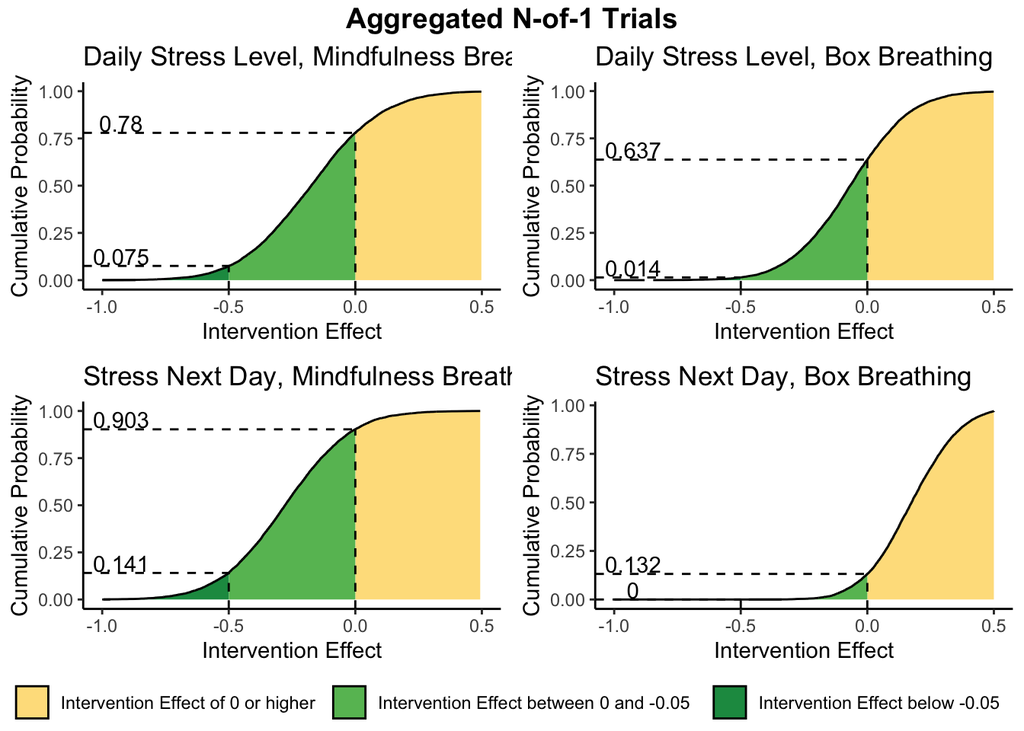

```r
plot_aggregated_daily_1 <- fct_aggregated_trials_cum_prob_plot(model = results_aggregated_primary_analysis[[2]], title = "Daily Stress Level, Mindfulness Breathing")

plot_aggregated_daily_2 <- fct_aggregated_trials_cum_prob_plot(model = results_aggregated_primary_analysis[[4]], title = "Daily Stress Level, Box Breathing")

plot_aggregated_next_day_1 <- fct_aggregated_trials_cum_prob_plot(model = results_aggregated_primary_analysis[[6]], title = "Stress Next Day, Mindfulness Breathing")

plot_aggregated_next_day_2 <- fct_aggregated_trials_cum_prob_plot(model = results_aggregated_primary_analysis[[8]], title = "Stress Next Day, Box Breathing")


plot_aggregated <- ggarrange(plot_aggregated_daily_1,
                             plot_aggregated_daily_2,
                             plot_aggregated_next_day_1,
                             plot_aggregated_next_day_2,
                             common.legend = TRUE,
                             legend = "bottom")
plot_aggregated <- annotate_figure(plot_aggregated,
                                   top = text_grob("Aggregated N-of-1 Trials", face = "bold", size = 14))

plot_aggregated
```

```r
ggsave("../results/Figure_4.jpg",
       plot_aggregated,
       height = 15,
       width = 20,
       units = "cm")
```